# edX - Statistics and R

Maurizio La Rosa

02/03/2021

# Normal Distribution Exercises

Load the femaleControlsPopulation data set. Here x represents the weights for the entire population.

Using the same process as before (in Null Distribution Exercises), set the seed at 1, then using a for-loop take a random sample of 5 mice 1,000 times. Save these averages. After that, set the seed at 1, then using a for-loop take a random sample of 50 mice 1,000 times. Save these averages.

We recommend you review the video and read the section on normal distribution in the book before tackling these problems:

http://genomicsclass.github.io/book/pages/random_variables.html#normal_distribution

## Normal Distribution Exercises #1

1 point possible (graded)

Use a histogram to “look” at the distribution of averages we get with a sample size of 5 and a sample size of 50. How would you say they differ?

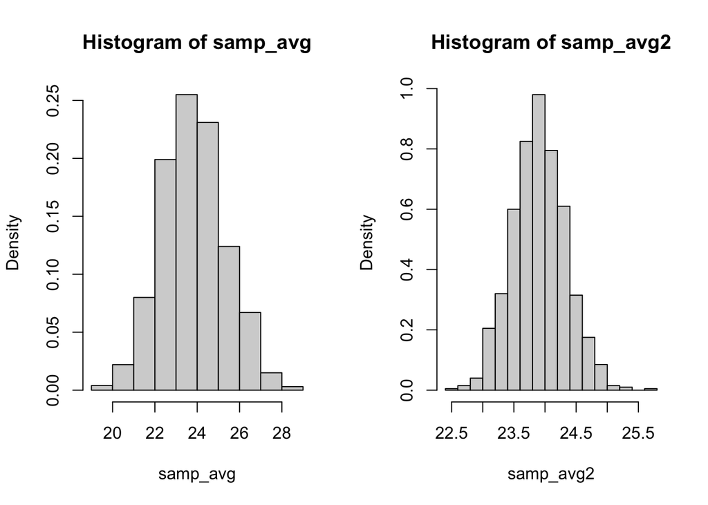

They both look roughly normal, but with a sample size of 50 the spread is smaller.

## Normal Distribution Exercises #2

1 point possible (graded)

For the last set of averages, the ones obtained from a sample size of 50, what proportion are between 23 and 25?

```
## [1] 0.982
```

## Normal Distribution Exercises #3

1 point possible (graded)

Now ask the same question of a normal distribution with average 23.9 and standard deviation 0.43.

```
## [1] 0.977
```